# Replication Log for Foster (2023) Subject to Change

Margaret J. Foster

2024-03-22

## Introduction

This document produces a replication log for the tables and figures made in R for Subject to Change: Quantifying Transformation in Armed Conflict Actors At Scale Using Text. STATA-produced tables are featured in accompanying scripts.

These results are generated from an R data file that was produced as part of the research, 01measurementScaleUpInProgressTiny55.Rdata. Replication code to produce the data can be found in the “01measurementFullDataTinyThreshRep.R” R script. Another data file, 02dfyearsumAndRelatedTinyUpdate.Rdata, is produced by “02tinyThreshTransformVarRep.R” in the replication package.

## Manuscript and Appendix Figure 1

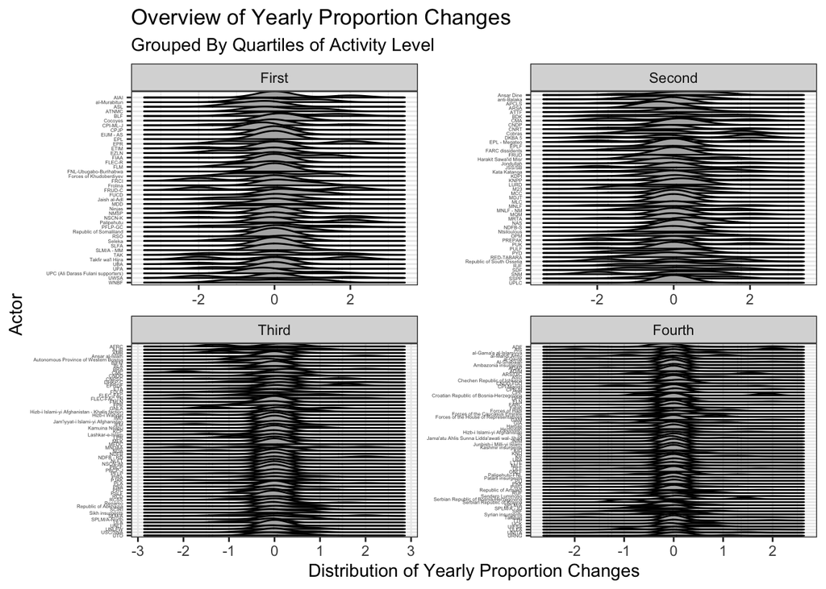

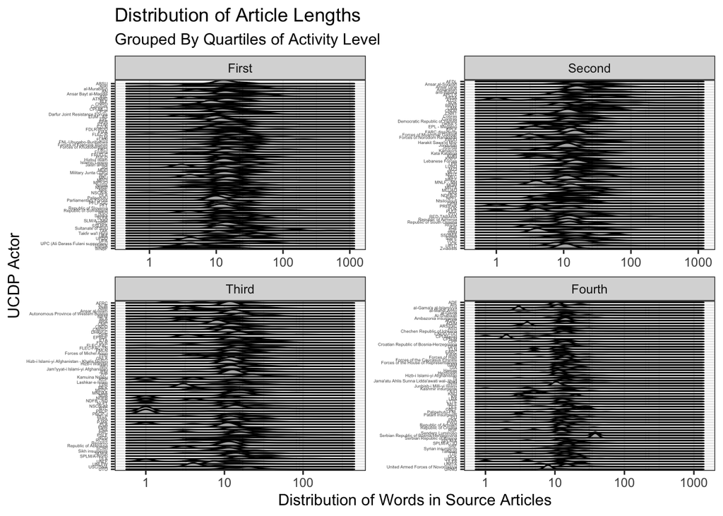

## Manuscript Table One and Appendix Figures 11 and 12

The following code prepares the data generated by the Subject To Change measurement for replication of Nilsson and Svensson (2021). The replication log for the Termination and Recurrence models are in the accompanying Stata Markdown output.

```
##
## % Table created by stargazer v.5.2.3 by Marek Hlavac, Social Policy Institute. E-mail: marek.hlavac at gmail.com
## % Date and time: Fri, Mar 22, 2024 - 11:09:42
## \begin{table}[!htbp] \centering
##   \caption{}
##   \label{}
## \begin{tabular}{@{\extracolsep{5pt}} ccc}
## \\[-1.8ex]\hline
## \hline \\[-1.8ex]
## Variable & No & Yes \\
## \hline \\[-1.8ex]
## Change year & 992 & 126 \\
## Change in Prev. 2 years & 894 & 224 \\
## Had 'Low' Change & 579 & 650 \\
## Had 'Med.' Change & 823 & 406 \\
## Had 'High' Change & 1028 & 201 \\
## \hline \\[-1.8ex]
## \end{tabular}
## \end{table}
```

```
##
## % Table created by stargazer v.5.2.3 by Marek Hlavac, Social Policy Institute. E-mail: marek.hlavac at gmail.com
## % Date and time: Fri, Mar 22, 2024 - 11:09:42
## \begin{table}[!htbp] \centering
##   \caption{}
##   \label{}
## \begin{tabular}{@{\extracolsep{5pt}}lccccc}
## \\[-1.8ex]\hline
## \hline \\[-1.8ex]
## Statistic & \multicolumn{1}{c}{N} & \multicolumn{1}{c}{Mean} & \multicolumn{1}{c}{St. Dev.} & \multicolumn{1}{c}{Min} & \multicolumn{1}{c}{Max} \\
## \hline \\[-1.8ex]
## Number of Changes & 1,114 & 1.061 & 1.166 & 0 & 4 \\
## Years Since Change & 1,118 & 0.830 & 2.057 & 0 & 16 \\
## \hline \\[-1.8ex]
## \end{tabular}
## \end{table}
```

[figure not shown]

```
## [1] "Finished making figures; Formatting data for STATA"
```

## Group Change-Year Plots

The following code replicates the group-year summary plots. These are Appendix Figures 2 (AQAP), 3 (Abu Sayyaf), 4 (ULFA), 5 (LRA), and Appendix Figure 10a (PKK)

```
## # A tibble: 32 × 2
##     year frexWords
##    <int> <chr>
##  1  1989 gaza,hama,israel,middl,strike,two,milit,raid,troop,soldier
##  2  1990 gaza,hama,israel,middl,strike,two,milit,raid,troop,soldier
##  3  1991 gaza,hama,israel,middl,strike,two,milit,raid,troop,soldier
##  4  1992 gaza,hama,israel,middl,strike,two,milit,raid,troop,soldier
##  5  1993 gaza,hama,israel,middl,strike,two,milit,raid,troop,soldier
##  6  1994 gaza,hama,israel,middl,strike,two,milit,raid,troop,soldier
##  7  1995 gaza,hama,israel,middl,strike,two,milit,raid,troop,soldier
##  8  1996 gaza,hama,israel,middl,strike,two,milit,raid,troop,soldier
##  9  1997 gaza,hama,israel,middl,strike,two,milit,raid,troop,soldier
## 10  1998 gaza,hama,israel,middl,strike,two,milit,raid,troop,soldier
## 11  1999 gaza,hama,israel,middl,strike,two,milit,raid,troop,soldier
## 12  2000 gaza,hama,israel,middl,strike,two,milit,raid,troop,soldier
```

[output cut: 20 more lines]

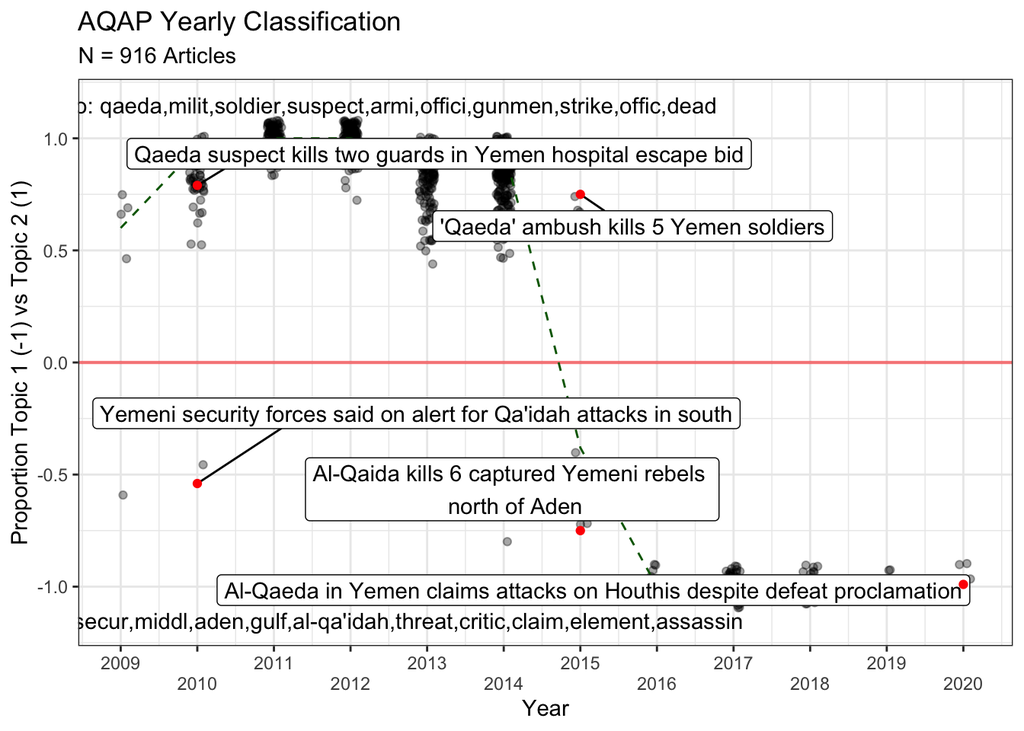

```
## # A tibble: 28 × 21
## # Groups:   groupID [1]
##     year countT1 countT2 propT1 propT2 propdiff propdif.L1 groupID frexWords
##    <int>   <int>   <int>  <dbl>  <dbl>    <dbl>      <dbl>   <int> <chr>
##  1  1993       2       0   1      0       -1        0          277 rebel,r,musl…
##  2  1994       6       0   1      0       -1        0          277 rebel,r,musl…
##  3  1995       6       0   1      0       -1        0          277 rebel,r,musl…
##  4  1996       6       0   1      0       -1        0          277 rebel,r,musl…
##  5  1997       8       0   1      0       -1        0          277 rebel,r,musl…
##  6  1998      10       0   1      0       -1        0          277 rebel,r,musl…
##  7  1999       3       1   0.75   0.25    -0.5      0.5        277 rebel,r,musl…
##  8  2000      29       4   0.88   0.12    -0.76    -0.26       277 rebel,r,musl…
##  9  2001      49       6   0.89   0.11    -0.78    -0.0200     277 rebel,r,musl…
## 10  2002      11      49   0.18   0.82     0.64     1.42       277 sayyaf,abu,s…
## # ℹ 18 more rows
## # ℹ 12 more variables: modeledarticles <int>, propdif.L2 <dbl>, delta1 <dbl>,
## #   delta1.5 <dbl>, delta2 <dbl>, delta1_L2 <dbl>, delta15_L2 <dbl>,
## #   delta2_L2 <dbl>, gap25 <dbl>, gap50 <dbl>, yearsSinceChange <lgl>,
## #   counter <dbl>
```

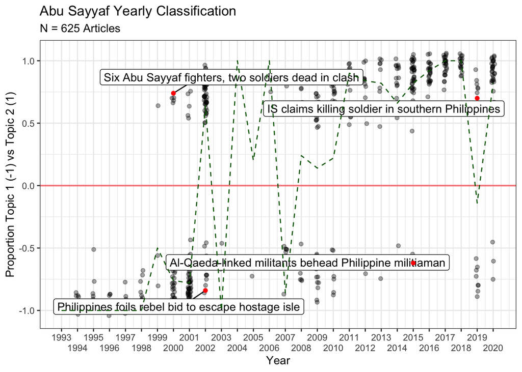

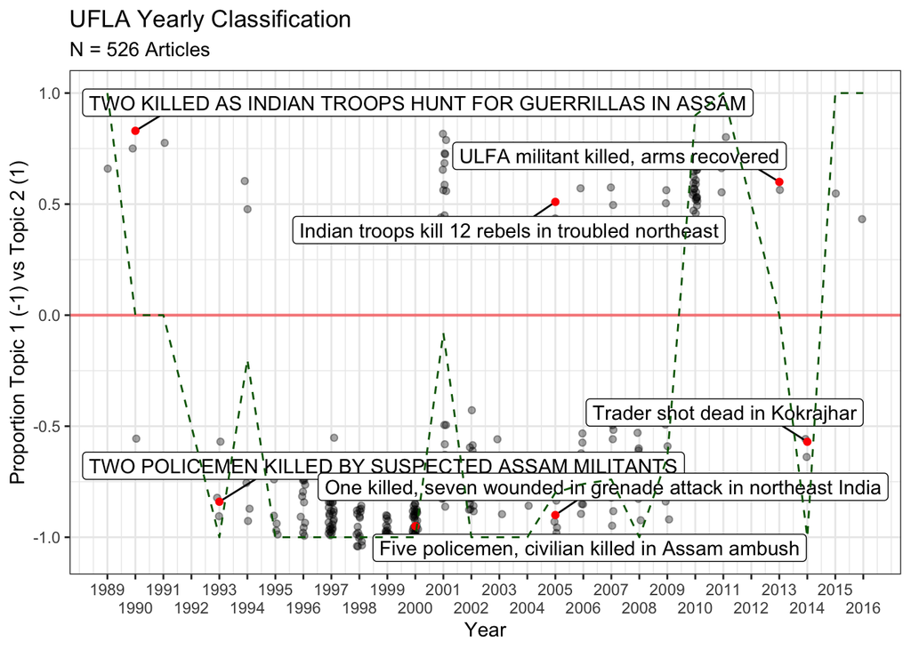

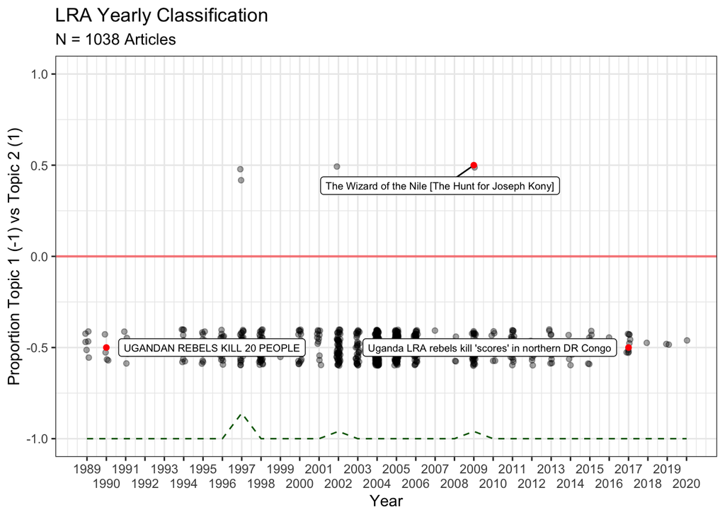

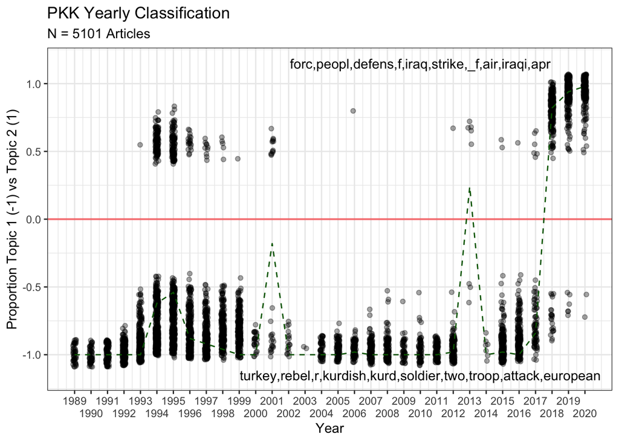

## Precision and Media Access Figures

The following code produces Appendix Figures 6 and 7, which evaluate the effect of media access on estimated change points.

These snippets address whether the approach is more likely to find changes in difficult reporting environments, which would suggest that what is being modeled is something other than behavioral changes.

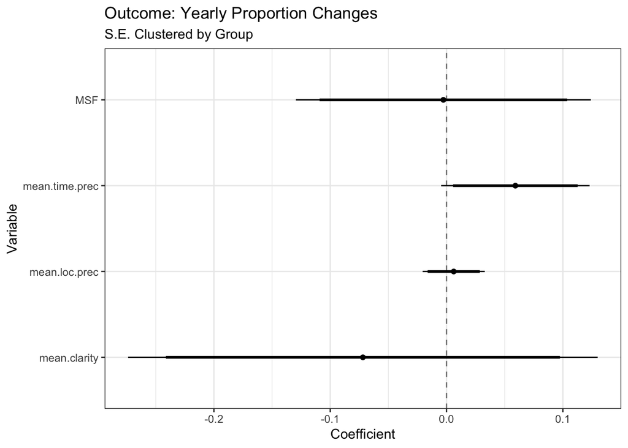

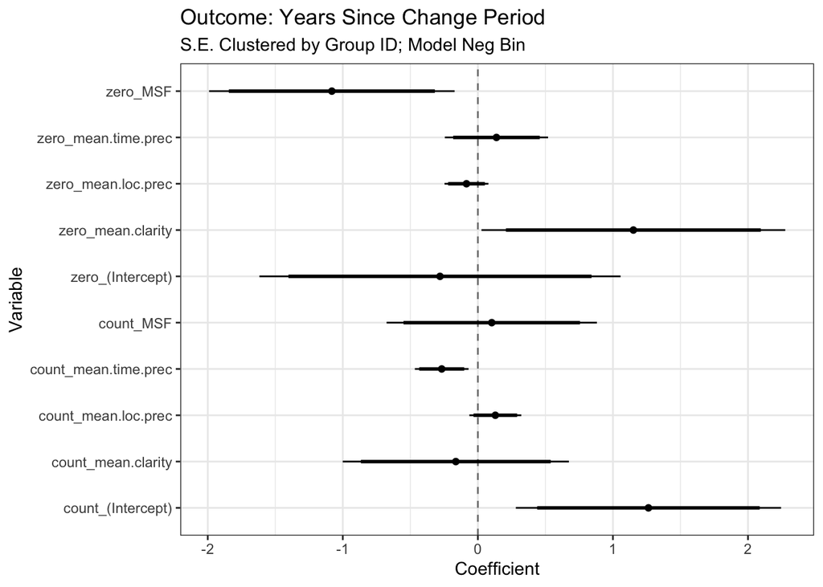

## Appendix AQAP Topic Comparison

The following code presents Table One of the Appendix, which presents a yearly summary for alternate model specifications for AQAP.

The following code presents Table One of the Appendix.

```
## [1] 5101   49
```

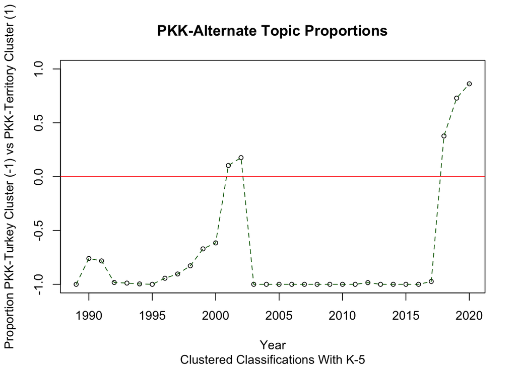

```
## [1] 916  49
##
## % Table created by stargazer v.5.2.3 by Marek Hlavac, Social Policy Institute. E-mail: marek.hlavac at gmail.com
## % Date and time: Fri, Mar 22, 2024 - 11:12:05
## \begin{table}[!htbp] \centering
##   \caption{}
##   \label{}
## \begin{tabular}{@{\extracolsep{5pt}} cccccccc}
## \\[-1.8ex]\hline
## \hline \\[-1.8ex]
## year & countT1 & countT2 & countT3 & propT1 & propT2 & propT3 & maxTopic \\
## \hline \\[-1.8ex]
## 2009 & 1 & 0 & 4 & 0.2 & 0 & 0.8 & 3 \\
## 2010 & 3 & 0 & 58 & 0.05 & 0 & 0.95 & 3 \\
## 2011 & 0 & 0 & 174 & 0 & 0 & 1 & 3 \\
## 2012 & 8 & 1 & 238 & 0.03 & 0 & 0.96 & 3 \\
## 2013 & 25 & 1 & 100 & 0.2 & 0.01 & 0.79 & 3 \\
## 2014 & 19 & 0 & 196 & 0.09 & 0 & 0.91 & 3 \\
## 2015 & 12 & 1 & 3 & 0.75 & 0.06 & 0.19 & 1 \\
## 2016 & 10 & 0 & 0 & 1 & 0 & 0 & 1 \\
## 2017 & 35 & 0 & 0 & 1 & 0 & 0 & 1 \\
## 2018 & 18 & 0 & 0 & 1 & 0 & 0 & 1 \\
## 2019 & 4 & 0 & 0 & 1 & 0 & 0 & 1 \\
## 2020 & 5 & 0 & 0 & 1 & 0 & 0 & 1 \\
## \hline \\[-1.8ex]
## \end{tabular}
## \end{table}
```